# MATH5741M: Statistical Theory and Methods

Benjamin Thorpe

2021-10-03

Benjamin Thorpe (b.thorpe@leeds.ac.uk)  
Sunday October 03, 2021

# Practical 1

To be successful in this module, you are expected to **attend all practicals**. The skills that you will develop in these practicals will be relevant to your coursework (worth $20\%$ of your module mark) and **will also be assessed in the final exam** (worth $80\%$ of your module mark).

The practicals are designed to be suitable for students with a wide range of abilities. Students with little knowledge of programming or statistics should be able to make good progress in each practical, but there should still be plenty to keep even very experienced students busy. You are not expected to complete every practical task in the given hour each week, but you should at least attempt the remaining questions in your own time with the help of the solutions (which will be uploaded after each practical).

## R and RStudio

Throughout this module we will work with the statistical programming language R (https://www.r-project.org/). Although it is possible to type commands directly into the R console, we will work with R through the integrated development environment RStudio (https://rstudio.com/). Please install R and then RStudio on your computer before the first practical.

[figure not shown]

Figure 1: A screenshot of the RStudio program, showing the console and an R script.

You are encouraged to complete the practical work in an R script, so that you can save it to view later or to work on in future practicals. This will also be important in the coursework, since you are encouraged to include the code from your R script in an appendix.

## Exercises

**Exercise 1 (basic commands)** What happens when you run each of the following lines of code **one by one**? Try to guess before running each line.

```r
4 * 2

sin(pi)

?sin

?pi
```

```r
a = 2

a

A

# a = 5

a
```

```r
b <- 3

b

4 -> b

sqrt(b)

b^2

b == 4

b == 2
```

**Exercise 2 (vectors)** An extremely helpful feature of R is the ability to easily work with vectors. Try typing the following commands one line at a time. Again, try to anticipate the outputs.

```r
c(1, 3, 2)

3 + c(1, 3, 2)

c(2, 3, 1) * c(5, 10, 20)

1:9

30:10
```

```r
v <- c(1, 3, 2)

v

v == c(1, 3, 4)

v[2]

v[c(2, 1)]

v[2:3]

v[2] <- 4

v
```

```r
w <- 4*c(0, 1, 4)

sqrt(w)

sum(w)

w <- 4

w
```

**Exercise 3 (odd numbers)** Try to write down a **single line** of code that will produce the square of every odd number from $3$ to $50$.

## Working with a script

We want to be able to save any code that we write. In the top left corner, click `File` then `New file` and then `R script`. This will open a new R script where you can write reusable code.

```r
setwd("C:/Users/benjamin/Desktop/R prac")
```

We can save this code by clicking `Save current document` at the top of the script.

## Exploring a data set

To load the `galaxies` data, we type and run

```r
load(file = "galaxies.Rdata")     # Don't forget the quotation marks.
```

We will work with this data set many times in this module, so it is important for us to become familiar with it. To show the first $10$ rows of the data set, type

```r
galaxies[1:10, ]
```

Each row contains data for a single galaxy. Typing `nrow(galaxies)` tells us the number of rows. Typing `names(galaxies)` tells us the names of the variables (columns) on which we have data. Typing `dim(galaxies)` gives us the numbers of rows and columns (respectively).

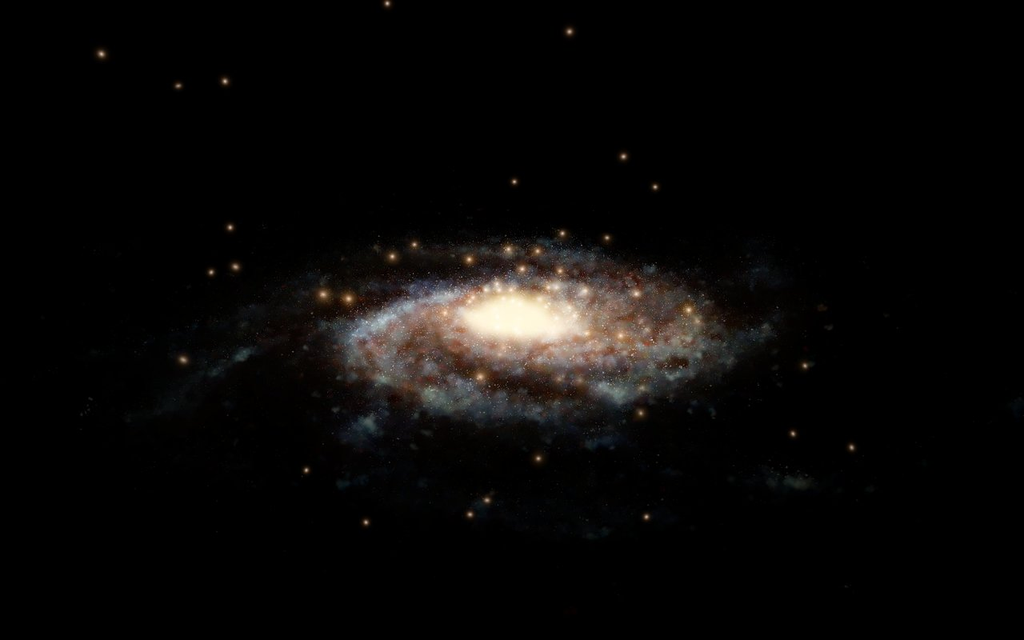

Figure 2: An artist’s impression of the Milky Way and its globular clusters. Credit: ESA/Hubble, NASA, L Calcada, M Kormesser. https://www.spacetelescope.org/videos/heic1905b

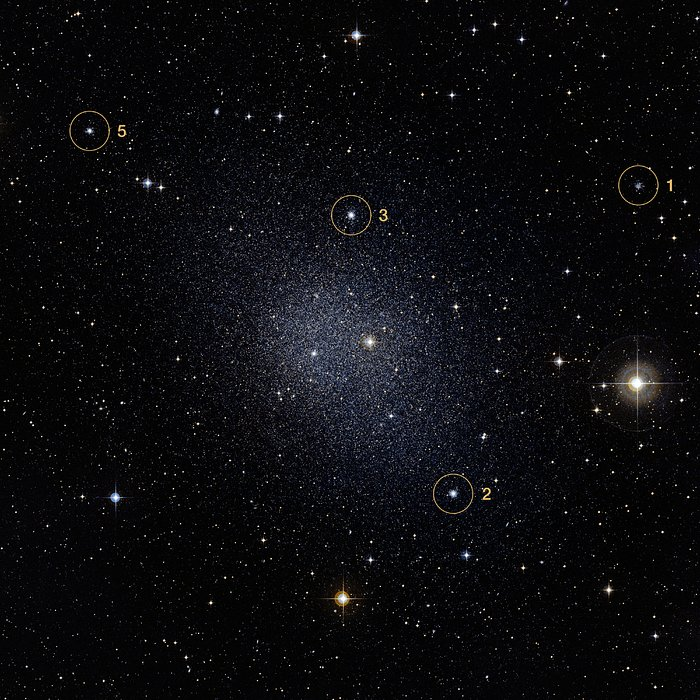

Figure 3: An image of the elliptical Fornax galaxy, with four of its globular clusters circled. Credit: ESO/Digitized Sky Survey 2. https://www.spacetelescope.org/images/heic1425g

Our variables are:

- `Galaxy`, the identifier/name of the galaxy.
- `GlobularClusters`, the number of globular star clusters orbiting the the core of the galaxy.
- `BlackHoleMass`, the mass of the black hole at the centre of the galaxy, on a logarithmic scale. A mass of $6$ means $10^6$ times the mass of our Sun.
- `Distance`, the distance from Earth in light-years. A distance of $10^9$ means light from the galaxy would take a billion years to reach us.
- `Vdispersion`, the velocity dispersion: how fast (in km/second) objects in the galaxy are moving relative to each other.
- `Eradius`, the effective radius: the radius (in light-years) at which half of the total light of the galaxy is emitted.
- `Type`, the visual appearance: Elliptical, Spiral or Lenticular.

To select the second variable, number of globular clusters, there are three options:

```r
galaxies[ , 2]

galaxies$GlobularClusters

galaxies[ , "GlobularClusters"]
```

To view these in order, from smallest to largest, we use the `sort()` function:

```r
sort(galaxies$GlobularClusters)
```

Now we check which galaxies have over $10000$ globular clusters by making a vector of `TRUE` or `FALSE` values:

```r
galaxies$GlobularClusters > 10000
```

We can count the number of such galaxies:

```r
sum(galaxies$GlobularClusters > 10000)
```

We can even identify specific observation numbers:

```r
which(galaxies$GlobularClusters > 10000)
```

```r
galaxies[galaxies$GlobularClusters > 10000, ]
```

To show only the name and type of these galaxies:

```r
galaxies[galaxies$GlobularClusters > 10000, c("Galaxy", "Type")]
```

To extract seventh variable of the first galaxy:

```r
galaxies[1, 7]
```

This is the visual type of the Milky Way galaxy, therefore we could have instead (using the equality operator, `==`) typed

```r
galaxies[galaxies$Galaxy == "MilkyWay", "Type"]
```

since `galaxies$Galaxy == "MilkyWay"` identifies which of the galaxies in our data set are called `"MilkyWay"`.

**Exercise 4 (spiral galaxies)** What line of code might we use to show the number of globular clusters for all galaxies whose whose type is `"Spiral"`?

## Manipulating a data set

The variable `BlackHoleMass` is the mass of the black hole at the centre of each galaxy, measured on a logarithmic scale. We can easily calculate **every** black hole mass in units of solar masses, instead of on the logarithmic scale:

```r
10^(galaxies$BlackHoleMass)
```

Store this vector in a variable called `y`:

```r
y <- 10^(galaxies$BlackHoleMass)
```

Run the code

```r
galaxies$BHM2 <- y
```

and then view the first $3$ lines of the `galaxies`. What do you see?

**Exercise 5 (distance from Earth)** The variable `Distance` gives the distance from each galaxy to Earth, in light-years. What code would we write to convert this distance to miles and then include it as a column in our data set?

It is also easy to remove rows and columns from a data set. For example,

```r
nonspiral <- galaxies[galaxies$Type != "Spiral", ]
```

will create a data set `nonspiral` containing only rows for galaxies that are not spiral galaxies (since `!=` means “not equal to”).

```r
manyclusters <- galaxies[galaxies$GlobularClusters >= 1000, ]
```

excludes all rows for galaxies with fewer than a thousand globular clusters (since `>=` means “greater than or equal to”).

```r
galaxies2 <- galaxies[ , -c(1, 3)]
```

doesn’t remove any galaxies from our data set, but it does remove columns $1$ and $3$.

We can see the impact on the amount of data by applying the `dim()` function:

```r
dim(galaxies)
dim(nonspiral)
dim(manyclusters)
dim(galaxies2)
```

If a column contains missing values, recorded as `NA`, it is often helpful to remove rows with missing values by using the `is.na()` function. For example,

```r
galaxies <- galaxies[!is.na(galaxies$Distance) , ]
```

will remove any rows for galaxies with no distance to Earth recorded. Has this changed our data set here? Try typing `is.na(galaxies$Distance)` and `!is.na(galaxies$Distance)` to explain. What do you think `!` does? Try typing `help("!")`.

## Loops

We often need to perform a task many times. For, example we might need to calculate an average for multiple columns of a very large data set. To avoid the need to write a line of code for each column, we could use a **for loop** that iterates over each column in the data set. We can illustrate this using our galaxies data:

```r
for(i in 2:6){
  print(sum(galaxies[ , i])/nrow(galaxies))
}
```

This code will print the averages of columns $2$, $3$, $4$, $5$ and $6$. In this loop, `for(i in 2:6)` says that everything inside the curly brackets `{ }` will be run for `i = 2`, `i = 3`, …, `i = 6`. Thus the calculation `sum(galaxies[ , i])/nrow(galaxies)` is performed for each index `i`, and the result will be printed thanks to the `print()` function.

We can also add **if statements**, to our loops. For example:

```r
for(i in 2:6){

  if(sum(galaxies[ , i])/nrow(galaxies) < 1000){

    print(sum(galaxies[ , i])/nrow(galaxies))
  }
}
```

Now the average of the $i$-th column will only be printed if it is less than $1000$. The condition inside `if()` can be any statement that produces a value of `TRUE` or `FALSE`, and the commands inside the subsequent curly brackets will only be performed by R if the statement is true.

Unlike some other programming languages, indentation is not necessary for loops in R. However, it is encouraged to make your code easier to follow.

**Exercise 6 (loops)** Run the following loop in R, then try to explain in plain English what this loop does.

```r
for(i in 1:nrow(galaxies)){

     if(galaxies$BlackHoleMass[i] > 9){

          print(galaxies[i, "Distance"]/1000)

     }
}
```

Using what we have learned in previous sections, how might this be achieved in a single line of code?

## Learning more about R

There are many **free** online resources available for learning R, for any level of ability in statistics or programming. I have included here some that I have found to be helpful in the past. For example, university lecturers often make their teaching materials available to the public. Particularly useful here are some introductory notes on R from Oxford and Cambridge:

- Evans R. R Programming. https://www.stats.ox.ac.uk/~evans/Rprog/
- Altham P. Introduction to Statistical Modelling in R. http://www.statslab.cam.ac.uk/~pat/redwsheets.pdf

Students with a fairly advanced understanding of linear regression might find the notes of Julian Faraway more helpful. These notes assume a greater level of mathematical ability, but they also offer much deeper insight into the analyses.

- Faraway J. Practical Regression and ANOVA using R. https://julianfaraway.github.io/faraway/PRA/

Anyone who who feels comfortable with the statistics and wants to focus entirely on learning R might prefer to read the early chapters of book of Norman Matloff. This book gives a particularly thorough introduction to the various data structures in R and how they are manipulated.

- Matloff N. The Art of R Programming. http://heather.cs.ucdavis.edu/~matloff/132/NSPpart.pdf